[figure not shown]

# 🛍️ Launch New Products

Today you are a machine learning engineer at the Department of New Products at Target Cosmetics!

We will start with a small dataset on interactions between users and current products from the past and try to discover substructure, if there's any, by applying some **unsupervised learning** methods.

Then we will leverage the small amount of labeled data (current products) in combination with a larger amount of unlabeled data (new products to launch) to make estimations as to which products will sell more.

## 📚 Learning Objectives

By the end of this session, you will be able to:

- apply dimensionality reduction techniques to reduce features to a lower dimensional space
- perform customer segmentation, determine optional number of clusters, and understand assumptions for used algorithm
- understand what semi-supervised learning is and leverage it to improve performance of supervised learning

## Task 1. Dimensionality Reduction

1. Load in the data.

   Import `pandas` as `pd` and use `pd.read_csv()` to read in `past.csv.gz` in the `dat` folder, saving it as `past`.

   Data in `past.csv.gz` was propcessed; e.g., features indicating time of day, day of week, month, and year of the purchase have been converted to one-hot representations of these categories.

```python
import pandas as pd

past = pd.read_csv('../dat/past.csv.gz')# YOUR CODE HERE
past.columns
```

```
Index(['product_id', 'user_id', 'NumOfEventsInJourney', 'NumSessions',
       'interactionTime', 'maxPrice', 'minPrice', 'NumCart', 'NumView',
       'NumRemove', 'InsessionCart', 'InsessionView', 'InsessionRemove',
       'Weekend', 'Fr', 'Mon', 'Sat', 'Sun', 'Thu', 'Tue', 'Wed', '2019',
       '2020', 'Jan', 'Feb', 'Oct', 'Nov', 'Dec', 'Afternoon', 'Dawn',
       'EarlyMorning', 'Evening', 'Morning', 'Night', 'Purchased?', 'Noon',
       'Category'],
      dtype='object')
```

**Expected output**

``` Index(['product_id', 'user_id', 'NumOfEventsInJourney', 'NumSessions', 'interactionTime', 'maxPrice', 'minPrice', 'NumCart', 'NumView', 'NumRemove', 'InsessionCart', 'InsessionView', 'InsessionRemove', 'Weekend', 'Fr', 'Mon', 'Sat', 'Sun', 'Thu', 'Tue', 'Wed', '2019', '2020', 'Jan', 'Feb', 'Oct', 'Nov', 'Dec', 'Afternoon', 'Dawn', 'EarlyMorning', 'Evening', 'Morning', 'Night', 'Purchased?', 'Noon', 'Category'], dtype='object') ```

1. What percentage of the interactions (rows) resulted in a purchase?

   Do people mostly buy what they look at or do they do a lot of "window shopping" (shopping around without buying)?

   From the perspective of classification, is the data balanced?

```python
past['Purchased?'].value_counts()# YOUR CODE HERE
```

```
0    3281
1    1719
Name: Purchased?, dtype: int64
```

```python
percent = (past['Purchased?'].value_counts()[1])/past.shape[0]
```

```python
print(f"{percent*100}","% of the interactions resulted in a purchase")
```

```
34.38 % of the interactions resulted in a purchase
```

1. Drop `product_id` and `user_id` and save the rest columns to a new `pd.DataFrame`:`X`; then pop the column `'Purchased?'` and save it to `y`.

```python
X = past.drop(columns=['product_id','user_id'],axis=1)# YOUR CODE HERE
y = X.pop('Purchased?')# YOUR CODE HERE
```

```python
assert X.shape == (5000, 34)
assert y.shape == (5000,)
```

```python
X.head(2)
```

|  | NumOfEventsInJourney | NumSessions | interactionTime | maxPrice | minPrice | NumCart | NumView | NumRemove | InsessionCart | InsessionView | ... | Nov | Dec | Afternoon | Dawn | EarlyMorning | Evening | Morning | Night | Noon | Category |
| --- | --- | --- | --- | --- | --- | --- | --- | --- | --- | --- | --- | --- | --- | --- | --- | --- | --- | --- | --- | --- | --- |
| 0 | 1.333333 | 1.333333 | 5550.0 | 15.84 | 15.840 | 0.00 | 1.333333 | 0.00 | 0.00 | 1.00 | ... | 0.00 | 0.00 | 0.00 | 0.0 | 0.666667 | 0.333333 | 0.0 | 0.0 | 0.0 | 1.0 |
| 1 | 2.250000 | 1.500000 | 27556.5 | 5.80 | 5.565 | 1.25 | 0.250000 | 0.25 | 3.75 | 2.25 | ... | 0.25 | 0.25 | 0.75 | 0.0 | 0.000000 | 0.250000 | 0.0 | 0.0 | 0.0 | 1.0 |

2 rows × 34 columns

1. Apply [PCA (check documentation if unfamiliar)](https://scikit-learn.org/stable/modules/generated/sklearn.decomposition.PCA.html) to reduce the number of features down to **5**, save it to a numpy array named `X_reduced`.

   Do you need to preprocess the data before performing PCA? Quick review [here: Importance of feature scaling](https://scikit-learn.org/stable/auto_examples/preprocessing/plot_scaling_importance.html).

   If time permits, read [Does mean centering or feature scaling affect a Principal Component Analysis?](https://sebastianraschka.com/faq/docs/pca-scaling.html) or [discussion 1](https://stats.stackexchange.com/questions/53/pca-on-correlation-or-covariance).

```python
# YOUR CODE HERE
import numpy as np
from sklearn.decomposition import PCA
from sklearn.preprocessing import StandardScaler
from sklearn.pipeline import make_pipeline

pca_pipeline = make_pipeline(StandardScaler(),PCA(n_components=5, whiten=True,random_state=42))
pca = pca_pipeline.named_steps['pca']
X_reduced = pca_pipeline.fit_transform(X)
```

```python
assert X_reduced.shape == (5000, 5)
```

1. Print out the percentage of variance explained by each of the selected components.

```python
print(pca.explained_variance_ratio_)# YOUR CODE HERE
```

```
[0.10281916 0.09445882 0.06506113 0.05100071 0.04255629]
```

```python
#X_scaled = StandardScaler().fit_transform(X) # YOUR CODE HERE - Alternative code panos
#assert X_scaled.shape == (5000, 34)
#pca = PCA(n_components=5,whiten=True)
#pca = pca.fit(X_scaled)
#X_reduced = pca.transform(X_scaled)
```

```python
#pca.explained_variance_ratio_# YOUR CODE HERE
#array([0.10282264, 0.09445352, 0.06501091, 0.05138654, 0.04303843])
```

```python
'''In PCA (Principal Component Analysis), "whiten=True" is an argument in the PCA function in some libraries
that indicates whether or not to normalize the data before running PCA.
If "whiten=True", it applies Z-score normalization to the data to make the features have zero
mean and unit variance. The purpose of this normalization is to make the features have equal importance
in the PCA analysis and to avoid large features dominating the results. This is also known as "whitening"
the data because it makes each feature have a covariance matrix equal to the identity matrix, which means
the data is uncorrelated and has unit variance.  ChatGPT'''
```

[output not shown]

```python
X_reduced
```

```
array([[ 0.31737321, -0.95302795,  0.78873959,  0.05452146,  0.26629586],
       [ 0.24157934,  0.00887822, -0.46597317, -0.04733608,  0.66432921],
       [-0.08742563, -0.65321287, -0.27980591, -0.33321059, -0.85210295],
       ...,
       [ 1.15897071, -1.3363618 , -0.73542136, -0.56801063,  1.01934914],
       [ 1.33850678, -1.10068387, -0.76131078,  0.19299725,  2.09589083],
       [-1.32092306,  0.19644611,  0.11462334, -0.30426123,  0.71137872]])
```

```python
X_reduced[:,1] # --> deuxieme colonne
```

```
array([-0.95302795,  0.00887822, -0.65321287, ..., -1.3363618 ,
       -1.10068387,  0.19644611])
```

```python
X_reduced[0:2,:]  # 2 premiere lignes
```

```
array([[ 0.31737321, -0.95302795,  0.78873959,  0.05452146,  0.26629586],
       [ 0.24157934,  0.00887822, -0.46597317, -0.04733608,  0.66432921]])
```

1. Review code in functions `visualize_2pcs` and `visualize_3pcs` below and visualize first few principal components in 2D and 3D plots, respectively:

```python
import matplotlib.pyplot as plt

def visualize_2pcs(pcs, y):
    fig, ax = plt.subplots()
    plot = plt.scatter(pcs[:,0], pcs[:,1], c=y)
    ax.legend(
        handles=plot.legend_elements()[0],
        labels=['No', 'Yes'])
```

```python
def visualize_3pcs(pcs, y):
    fig, ax = plt.subplots()
    ax = fig.add_subplot(projection='3d')
    plot = ax.scatter(pcs[:,0], pcs[:,1], pcs[:,2], c=y)
    ax.legend(
        handles=plot.legend_elements()[0],
        labels=['No', 'Yes'])
```

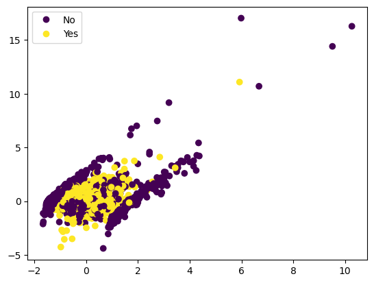

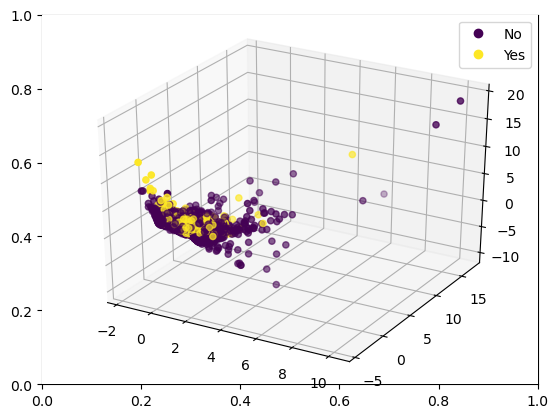

```python
visualize_2pcs(X_reduced,y)# YOUR CODE HERE Assumes 2 dimensions (egenvector) have the knowledge
visualize_3pcs(X_reduced,y)# YOUR CODE HERE Assumes 3 dimensions have the knowledge
```

1. One way to assess the quality of the dimensionality reduction, when the groundtruth is available of course, is comparing the prediction performance using given features vs reduced (engineered) features.

     1) preprocessing data using standardization if the `standardize` is `True`; otherwise skip this step

     2) apply logistic regression ( are the labels balanced? )
   - fit the pipeline using training data
   - print the classification report (use `sklearn.metrics.classification_report`) on test data

```python
# YOUR CODE HERE (imports!)
from sklearn.linear_model import LogisticRegression
from sklearn.model_selection import train_test_split
from sklearn.pipeline import Pipeline
from sklearn.metrics import accuracy_score, precision_score, recall_score, f1_score, roc_auc_score, confusion_matrix
from sklearn.metrics import classification_report
from sklearn.preprocessing import StandardScaler


def train(X, y, standardize = True) -> None:

    X_train, X_test, y_train, y_test = train_test_split(X, y, test_size=0.2, random_state=42)

    if standardize == True:
        pipeline = Pipeline(steps=[('scaler', StandardScaler()),
                    ('logistic_regression', LogisticRegression(class_weight='balanced'))]).fit(X_train, y_train)
    else:
        pipeline = Pipeline(steps=[('logistic_regression',
                                    LogisticRegression(class_weight='balanced'))]).fit(X_train, y_train)

    y_pred = pipeline.predict(X_test)
    print(classification_report(y_test, y_pred,target_names=['No','Yes - Purchased']))
    print("")
    print("accuracy:", accuracy_score(y_test, y_pred))
    print("precision:", precision_score(y_test, y_pred))
    print("recall:", recall_score(y_test, y_pred))
    print("f1 score:", f1_score(y_test, y_pred))
    print("roc auc score:", roc_auc_score(y_test, y_pred))
    print("confusion matrix:")
    print(confusion_matrix(y_test, y_pred))
```

Now apply the pipeline on the all the features `X` and review the performance

```python
train(X, y)# YOUR CODE HERE
```

```
                 precision    recall  f1-score   support

             No       0.76      0.77      0.76       659
Yes - Purchased       0.54      0.53      0.54       341

       accuracy                           0.69      1000
      macro avg       0.65      0.65      0.65      1000
   weighted avg       0.69      0.69      0.69      1000


accuracy: 0.688
precision: 0.5435435435435435
recall: 0.530791788856305
f1 score: 0.5370919881305637
roc auc score: 0.6500696425313391
confusion matrix:
[[507 152]
 [160 181]]
```

Similarly, apply the pipeline on the reduced / engineered features `X_reduced`. Should you include standardization in the pipeline?

```python
train(X_reduced, y, standardize=False)# YOUR CODE HERE
```

```
                 precision    recall  f1-score   support

             No       0.74      0.68      0.71       659
Yes - Purchased       0.47      0.54      0.50       341

       accuracy                           0.63      1000
      macro avg       0.60      0.61      0.60      1000
   weighted avg       0.65      0.63      0.64      1000


accuracy: 0.633
precision: 0.46683673469387754
recall: 0.5366568914956011
f1 score: 0.49931787175989084
roc auc score: 0.6097548493896822
confusion matrix:
[[450 209]
 [158 183]]
```

1. Are the results as expected? Discuss the pros and cons using reduced set of features in this application with your teammate.  
   *We observe similar performance with less data - so it is useful on a computational standpoint*

## Task 2. Customer Segmentation

In this task, we apply k-means clustering on the reduced data, experimenting different vaules of `n_cluster`, summarize all this information in a single plot, the *Elbow* plot. In addition, leverage silhouette visualization to help decide the "optimal" number of clusters in our data and answer:

1. Are there any patterns among customer purchasing behaviors?
2. If so, what categories do they belong to? How do you characterize the clusters?
3. If not, what followup steps and / or recommendations will you make as an MLE?
1. Look up the [documentation](https://scikit-learn.org/stable/modules/clustering.html) and import the model class for k-means from `sklearn.cluster`

```python
from sklearn.cluster import KMeans# YOUR CODE HERE
```

1. Complete `visualize_elbow`; inspect the code and complete
   - fit k-means on the given data `X` and `k`, setting `random_state` to be 10 for reproducibility
   - append the sum of squared distances of samples to their closest cluster center for each $k$ to list `inertias`

```python
def visualize_elbow(X, ks):
    fig, ax = plt.subplots()
    inertias = []
    for k in ks:
        kmeans = KMeans(n_clusters=k, random_state=10).fit(X)
        inertias.append(kmeans.inertia_) # YOUR CODE HERE
    plt.plot(ks, inertias)
    plt.xticks(ks)
    plt.xlabel('Number of clusters')
    plt.ylabel('Inertia')
    plt.title('Elbow plot')
```

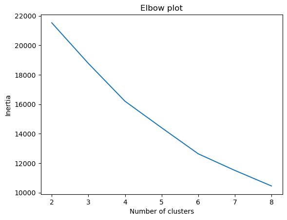

```python
visualize_elbow(X_reduced, [2,3,4,5,6,7,8])# YOUR CODE HERE [red warning python version to change]
```

1. What are the disadvantage to use the Elbow method?

```
*It is hard to figure out where is the inflexion point (elbow)*
```

1. Let's try a different approach: [silhouette score](https://towardsdatascience.com/clustering-metrics-better-than-the-elbow-method-6926e1f723a6).

   A helper function `visualize_silhouette` is provided for you (inspect the code in `utils.py`) and figure out how to use it to visualize k-means for k ranges from 2 to 8 on the reduced data.

```python
from utils import visualize_silhouette
```

```python
import warnings
warnings.filterwarnings("ignore") # to remove the red lines
```

```
For n_clusters = 2 The average silhouette_score is : 0.20000076688620105
For n_clusters = 3 The average silhouette_score is : 0.21024389546644634
For n_clusters = 4 The average silhouette_score is : 0.21948064643365234
For n_clusters = 5 The average silhouette_score is : 0.22511944439172166
For n_clusters = 6 The average silhouette_score is : 0.2114012680676948
For n_clusters = 7 The average silhouette_score is : 0.21261668185265511
For n_clusters = 8 The average silhouette_score is : 0.22080792678147845
```

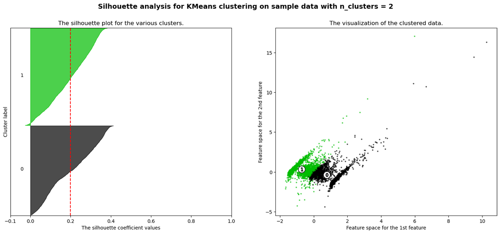

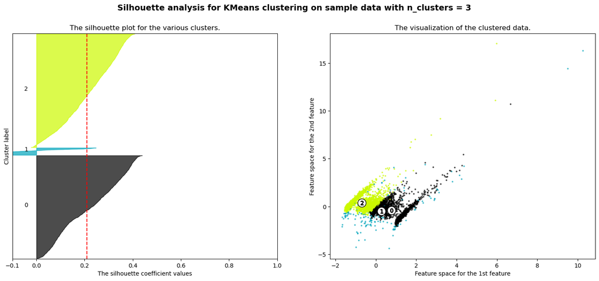

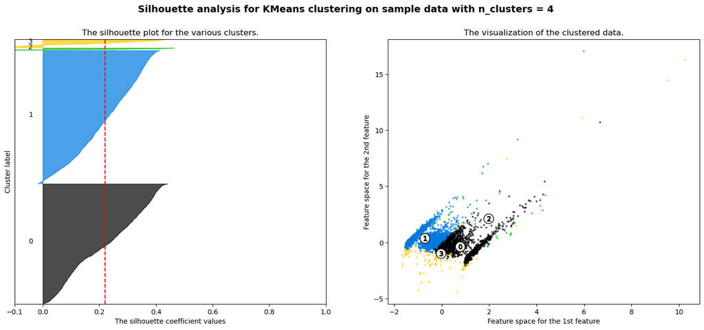

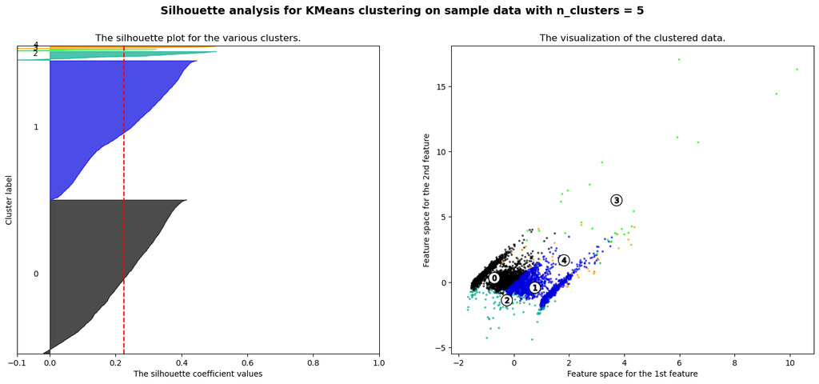

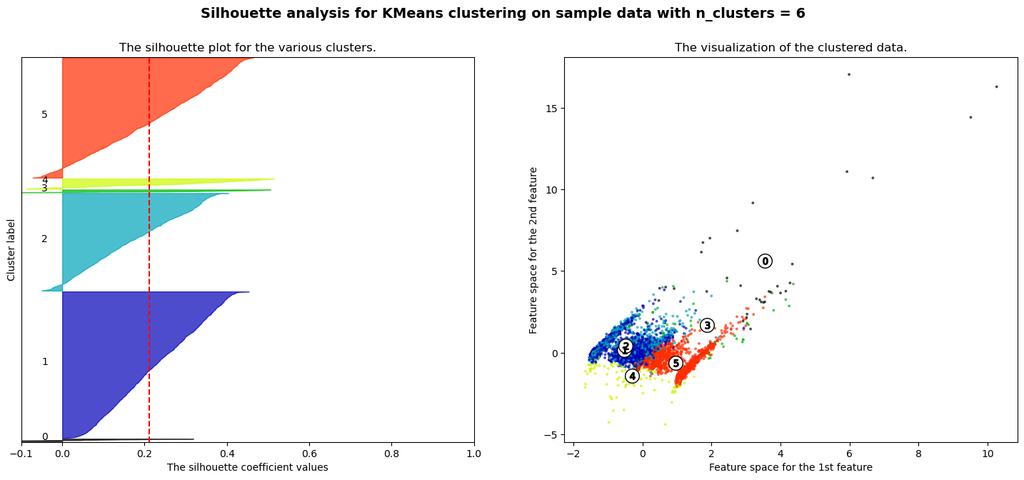

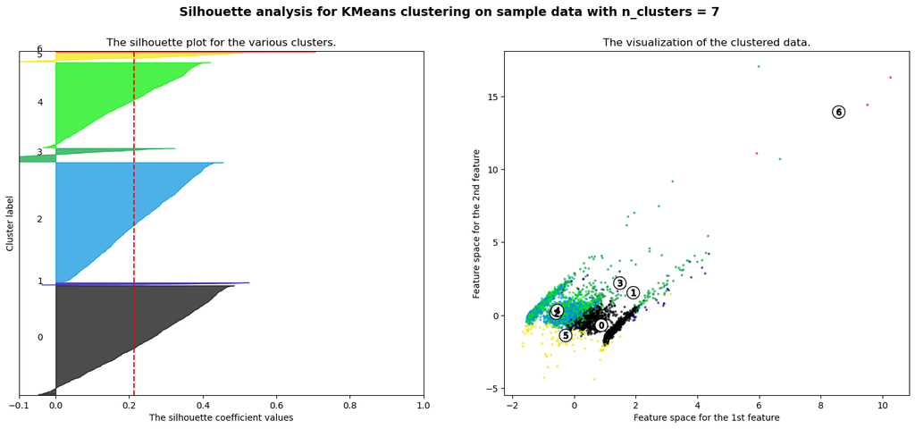

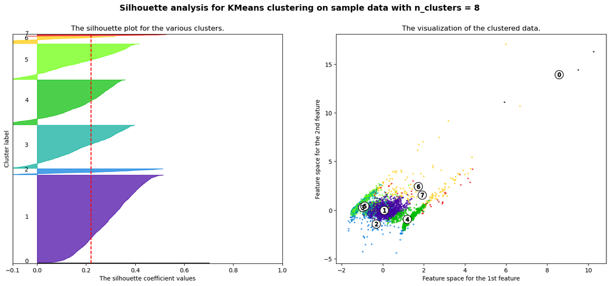

```python
visualize_silhouette(8, X_reduced, random_state=10)# utils has the code # YOUR CODE HERE
```

1. Instantiate a k-means model using the number of cluster that you deem optimal, assign it to `km`, and fit on the reduced data.

```python
KMeans(n_clusters=4, random_state=10)# YOUR CODE HERE nbviewer.org????
```

```
KMeans(n_clusters=4, random_state=10)
```

When returning to the NB the message below appears: KMeans(n_clusters=4, random_state=10) In a Jupyter environment, please rerun this cell to show the HTML representation or trust the notebook. On GitHub, the HTML representation is unable to render, please try loading this page with nbviewer.org.

```python
kmeans = KMeans(n_clusters=4, random_state=10)
kmeans.fit(X_reduced)
```

```
KMeans(n_clusters=4, random_state=10)
```

1. What is the size of each cluster?

```python
kmeans.labels_
```

```
array([0, 0, 0, ..., 0, 0, 1], dtype=int32)
```

```python
resultats = kmeans.labels_.tolist() # transforming the ndarray to a list
resultats.count(1)
```

```
2535
```

```python
for x in range(4):
    print("The size of Cluster",x," is of ",resultats.count(x)," observations")# YOUR CODE HERE
```

```
The size of Cluster 0  is of  2281  observations
The size of Cluster 1  is of  2535  observations
The size of Cluster 2  is of  37  observations
The size of Cluster 3  is of  147  observations
```

```python
labels = kmeans.labels_
labels_count = [0]*4
for x in labels:
    labels_count[x] = labels_count[x]+1
for x in range(len(labels_count)):
    print("Cluster",x,": ",labels_count[x])
# YOUR CODE HERE ca marche aussi
```

```
Cluster 0 :  2281
Cluster 1 :  2535
Cluster 2 :  37
Cluster 3 :  147
```

```python
labels_count # WHY ARE LABELS NOT ORGANIZED??
```

```
[2281, 2535, 37, 147]
```

1. Create a new column called `cluster_pca` in `past`, with values as predicted cluster index predicted by `km`.

```python
past.head()# YOUR CODE HERE
```

|  | product_id | user_id | NumOfEventsInJourney | NumSessions | interactionTime | maxPrice | minPrice | NumCart | NumView | NumRemove | ... | Dec | Afternoon | Dawn | EarlyMorning | Evening | Morning | Night | Purchased? | Noon | Category |
| --- | --- | --- | --- | --- | --- | --- | --- | --- | --- | --- | --- | --- | --- | --- | --- | --- | --- | --- | --- | --- | --- |
| 0 | 5866936 | 5.618978e+08 | 1.333333 | 1.333333 | 5550.000 | 15.84000 | 15.84000 | 0.00 | 1.333333 | 0.00 | ... | 0.00 | 0.000 | 0.0 | 0.666667 | 0.333333 | 0.00 | 0.00 | 0 | 0.00 | 1.0 |
| 1 | 5647110 | 5.326529e+08 | 2.250000 | 1.500000 | 27556.500 | 5.80000 | 5.56500 | 1.25 | 0.250000 | 0.25 | ... | 0.25 | 0.750 | 0.0 | 0.000000 | 0.250000 | 0.00 | 0.00 | 0 | 0.00 | 1.0 |
| 2 | 5790472 | 4.578109e+08 | 1.000000 | 1.000000 | 0.000 | 6.27250 | 6.27250 | 0.25 | 0.750000 | 0.00 | ... | 0.00 | 0.000 | 0.0 | 0.000000 | 0.750000 | 0.25 | 0.00 | 0 | 0.00 | 1.0 |
| 3 | 5811598 | 4.612641e+08 | 1.500000 | 1.500000 | 131532.500 | 5.56000 | 5.56000 | 0.25 | 1.000000 | 0.25 | ... | 0.25 | 0.000 | 0.0 | 0.000000 | 0.500000 | 0.00 | 0.25 | 0 | 0.25 | 1.0 |
| 4 | 5846363 | 5.157993e+08 | 1.875000 | 1.375000 | 11055.875 | 4.08625 | 4.08625 | 0.50 | 1.000000 | 0.25 | ... | 0.25 | 0.375 | 0.0 | 0.125000 | 0.250000 | 0.25 | 0.00 | 1 | 0.00 | 1.0 |

5 rows × 37 columns

```python
print(past.shape,len(kmeans.labels_))
```

```
(5000, 37) 5000
```

```python
past['cluster_pca']=kmeans.labels_
```

```python
past.head()
```

|  | product_id | user_id | NumOfEventsInJourney | NumSessions | interactionTime | maxPrice | minPrice | NumCart | NumView | NumRemove | ... | Afternoon | Dawn | EarlyMorning | Evening | Morning | Night | Purchased? | Noon | Category | cluster_pca |
| --- | --- | --- | --- | --- | --- | --- | --- | --- | --- | --- | --- | --- | --- | --- | --- | --- | --- | --- | --- | --- | --- |
| 0 | 5866936 | 5.618978e+08 | 1.333333 | 1.333333 | 5550.000 | 15.84000 | 15.84000 | 0.00 | 1.333333 | 0.00 | ... | 0.000 | 0.0 | 0.666667 | 0.333333 | 0.00 | 0.00 | 0 | 0.00 | 1.0 | 0 |
| 1 | 5647110 | 5.326529e+08 | 2.250000 | 1.500000 | 27556.500 | 5.80000 | 5.56500 | 1.25 | 0.250000 | 0.25 | ... | 0.750 | 0.0 | 0.000000 | 0.250000 | 0.00 | 0.00 | 0 | 0.00 | 1.0 | 0 |
| 2 | 5790472 | 4.578109e+08 | 1.000000 | 1.000000 | 0.000 | 6.27250 | 6.27250 | 0.25 | 0.750000 | 0.00 | ... | 0.000 | 0.0 | 0.000000 | 0.750000 | 0.25 | 0.00 | 0 | 0.00 | 1.0 | 0 |
| 3 | 5811598 | 4.612641e+08 | 1.500000 | 1.500000 | 131532.500 | 5.56000 | 5.56000 | 0.25 | 1.000000 | 0.25 | ... | 0.000 | 0.0 | 0.000000 | 0.500000 | 0.00 | 0.25 | 0 | 0.25 | 1.0 | 0 |
| 4 | 5846363 | 5.157993e+08 | 1.875000 | 1.375000 | 11055.875 | 4.08625 | 4.08625 | 0.50 | 1.000000 | 0.25 | ... | 0.375 | 0.0 | 0.125000 | 0.250000 | 0.25 | 0.00 | 1 | 0.00 | 1.0 | 1 |

5 rows × 38 columns

1. Open ended: manipulate `past` and see if you can characterize each cluster (e.g., calculate statistics of / visualize features for each cluster), how will you intepret the results?

   **Note**. This is probably the most important part as far as the business stakeholders are concerned: "*What can I do with your results?*" The math, modeling part is relatively easy, compared to actionable recommendations you make for business. Thus, before jumping on a different algorithm for the given task, do you best to 1) understand the data in depth 2) keep buisiness use cases in mind throughout all steps.

```python
toto = past.groupby('cluster_pca').describe().T
toto.loc['Purchased?']
```

| cluster_pca | 0 | 1 | 2 | 3 |
| --- | --- | --- | --- | --- |
| count | 2281.000000 | 2535.000000 | 37.000000 | 147.000000 |
| mean | 0.328803 | 0.357791 | 0.054054 | 0.408163 |
| std | 0.469881 | 0.479445 | 0.229243 | 0.493174 |
| min | 0.000000 | 0.000000 | 0.000000 | 0.000000 |
| 25% | 0.000000 | 0.000000 | 0.000000 | 0.000000 |
| 50% | 0.000000 | 0.000000 | 0.000000 | 0.000000 |
| 75% | 1.000000 | 1.000000 | 0.000000 | 1.000000 |
| max | 1.000000 | 1.000000 | 1.000000 | 1.000000 |

```python
toto.loc[['minPrice','maxPrice']]
```

|  | cluster_pca | 0 | 1 | 2 | 3 |
| --- | --- | --- | --- | --- | --- |
| minPrice | count | 2281.000000 | 2535.000000 | 37.000000 | 147.000000 |
|  | mean | 6.172221 | 5.653537 | 4.364459 | 58.228334 |
|  | std | 5.721737 | 5.220871 | 4.091700 | 34.071393 |
|  | min | 0.000000 | 0.000000 | 0.000000 | 1.350000 |
|  | 25% | 2.520000 | 2.380000 | 1.430000 | 38.810000 |
|  | 50% | 4.506667 | 4.130000 | 3.756667 | 46.490000 |
|  | 75% | 7.460000 | 6.782000 | 6.380000 | 63.297373 |
|  | max | 39.680000 | 33.810000 | 17.460000 | 236.510000 |
| maxPrice | count | 2281.000000 | 2535.000000 | 37.000000 | 147.000000 |
|  | mean | 6.205091 | 5.676510 | 4.789414 | 58.279100 |
|  | std | 5.739312 | 5.225111 | 3.872665 | 34.075641 |
|  | min | 0.000000 | 0.000000 | 0.000000 | 1.590000 |
|  | 25% | 2.540000 | 2.380000 | 1.590000 | 38.810000 |
|  | 50% | 4.585000 | 4.140000 | 4.020000 | 46.670000 |
|  | 75% | 7.460000 | 6.830000 | 6.380000 | 63.351186 |
|  | max | 39.680000 | 33.810000 | 17.460000 | 236.510000 |

```
Estimated revenue from group 1:  0.328803 x 2281 x 6.172221 = 4,629 dollars
                        group 2: 0.357791 x 2535 x 5.653537 = 5,127 ---> favor group 2
                        group 3: 0.054054 x 37 x 4.364459   = 9
                        group 4: 0.408163 x 147 x 58.228334 = 3,494
```

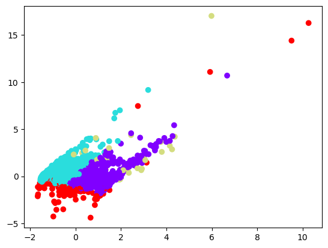

```python
plt.scatter(X_reduced[:,0], X_reduced[:,1], c=kmeans.labels_, cmap='rainbow') # nicer choice of colors

plt.show() # group1 bleue clair / groupe 2; violet / 3 vert / 4 rouge ??? how can I see kernel
```

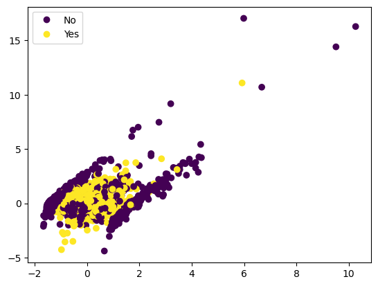

```python
visualize_2pcs(X_reduced,y)
# intersect yellow and purple is the highest?
```

1. What are the assumptions for k-means? Judging by the cluster sizes, is k-means a good approach?

   Scanning the list of [clustering algorithms](https://scikit-learn.org/stable/modules/clustering.html) implemented in scikit-learn, try at least one other algorithm, examine its assumptions, and intepret results.

```
One of k-meams Assumptions is that the clusters would be of the same size. The 2 top clusters are.
```

(From ChatGPT) The K-Means clustering algorithm makes several assumptions about the data:

Symmetry: The mean of the data in each cluster should be symmetrical.  
Independence: The data points within each cluster should be independent and not related to each other.  
Equal Variance: The variance of the data points within each cluster should be approximately equal.  
Round Shapes: The clusters should have a round or spherical shape. This is because K-Means measures the distance between data points to determine their cluster assignment.  
Same Size: The clusters should have roughly the same number of data points.  
These assumptions are important to keep in mind because they can affect the performance and accuracy of the K-Means algorithm. If the data does not meet these assumptions, it may be necessary to transform the data or use a different clustering algorithm.

```python
# YOUR CODE HERE - another try
from sklearn.cluster import DBSCAN
dbscan = DBSCAN(eps=1,min_samples = 50)
dbclusters = dbscan.fit_predict(X_reduced)
labels = dbscan.labels_
past['dbscan']=dbclusters
'''The eps parameter sets the maximum distance between two points for them to
be considered as part of the same cluster, and min_samples sets the minimum number
of samples required to form a dense region.'''
past.groupby('dbscan').describe().T.loc['Purchased?',:]
```

| dbscan | -1 | 0 |
| --- | --- | --- |
| count | 431.000000 | 4569.000000 |
| mean | 0.206497 | 0.356752 |
| std | 0.405261 | 0.479093 |
| min | 0.000000 | 0.000000 |
| 25% | 0.000000 | 0.000000 |
| 50% | 0.000000 | 0.000000 |
| 75% | 0.000000 | 1.000000 |
| max | 1.000000 | 1.000000 |

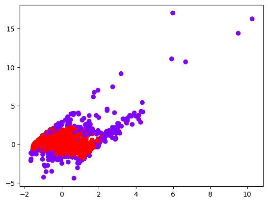

```python
plt.scatter(X_reduced[:,0], X_reduced[:,1], c=labels, cmap='rainbow')
plt.show() # red covers the yelloe
```

1. Jot down recommendations or followup steps, detailing the reasons.

Interpret the higher level variable. What is it made of? Pick the variable that we can control Filter the X to keep only the purchase to see the coverage better